# Loxahatchee River-Lake Worth Creek Aquatic Preserve

SEACAR Water Quality Analysis

Last compiled on 15 July, 2026

# Indicators

## Nutrients

### Total Nitrogen - Discrete

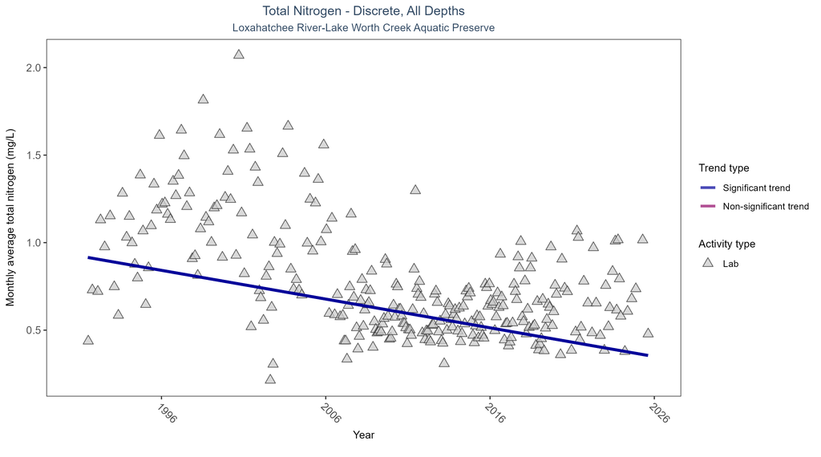

Scatter plot of monthly average total nitrogen over time. If the time series included ten or more years of discrete observations, a significant (blue) or non-significant (magenta) trend line is also shown. Only nitrogen values obtained from laboratory analyses (triangles) are included in the plot.

Table:

Monthly average total nitrogen decreased by 0.02 mg/L per year.

| Activity Type | Statistical Trend | Sample Count | Years with Data | Period of Record | Median Result Value | Tau | Sen Intercept | Sen Slope | P |
| --- | --- | --- | --- | --- | --- | --- | --- | --- | --- |
| Lab | Decreasing trend | 4775 | 35 | 1991 - 2025 | 0.706 | -0.27174 | 0.92384 | -0.01642 | 0 |

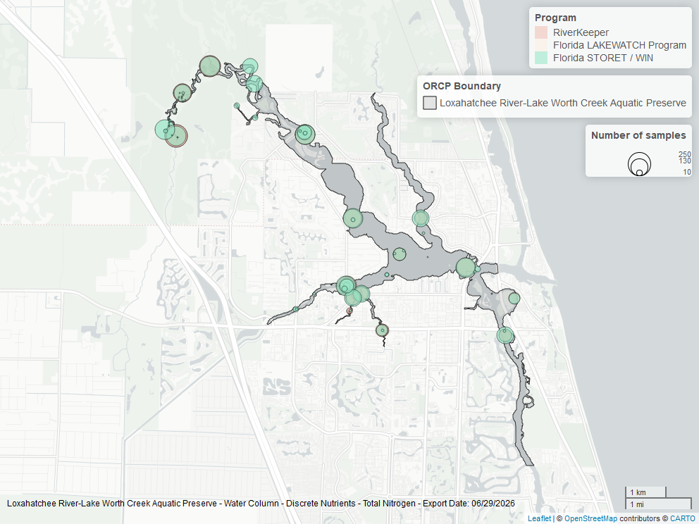

Map showing location of discrete water quality sampling locations within the boundaries of *Loxahatchee River-Lake Worth Creek Aquatic Preserve*. The bubble size on the maps above reflect the amount of data available at each sampling site.

### Total Phosphorus - Discrete

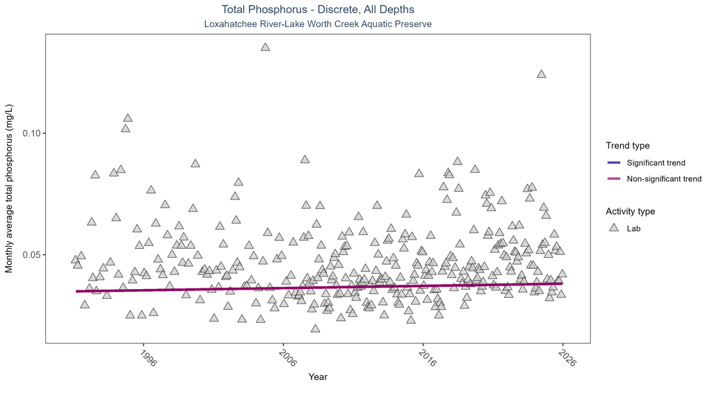

Scatter plot of monthly average total phosphorus over time. If the time series included ten or more years of discrete observations, a significant (blue) or non-significant (magenta) trend line is also shown. Only phosphorus values obtained from laboratory analyses (triangles) are included in the plot.

Table:

Total phosphorus showed no detectable trend between 1991 and 2025.

| Activity Type | Statistical Trend | Sample Count | Years with Data | Period of Record | Median Result Value | Tau | Sen Intercept | Sen Slope | P |
| --- | --- | --- | --- | --- | --- | --- | --- | --- | --- |
| Lab | No detectable trend | 6759 | 35 | 1991 - 2025 | 0.042 | 0.06964 | 0.03492 | 0.00009 | 0.2154 |

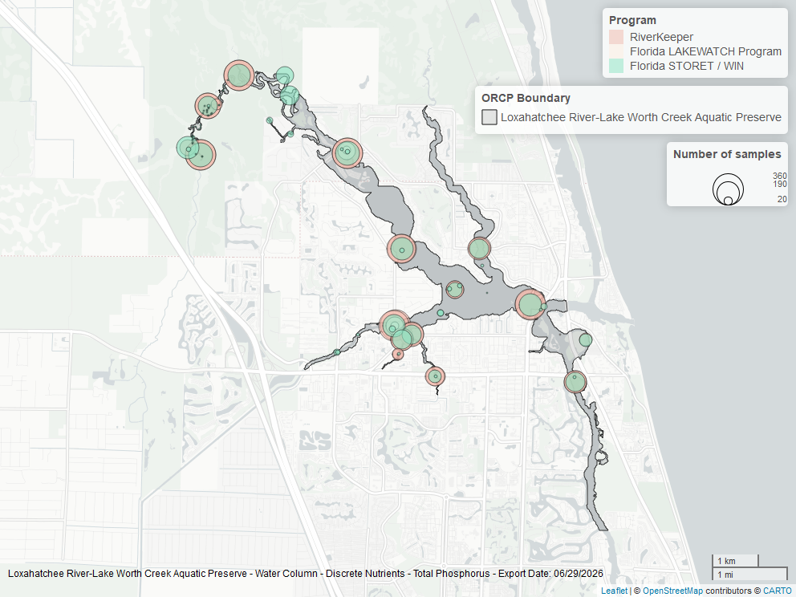

Map showing location of discrete water quality sampling locations within the boundaries of *Loxahatchee River-Lake Worth Creek Aquatic Preserve*. The bubble size on the maps above reflect the amount of data available at each sampling site.

## Water Quality

### Dissolved Oxygen - Discrete

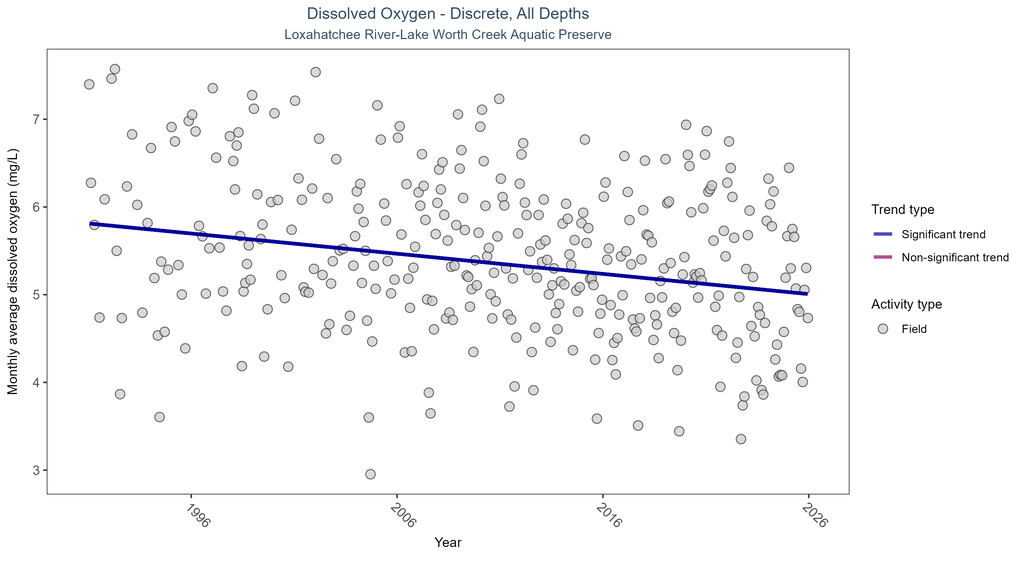

Scatter plot of monthly average dissolved oxygen over time. If the time series included ten or more years of discrete observations, a significant (blue) or non-significant (magenta) trend line is also shown. Only dissolved oxygen values measured in the field (circles) are included in the plot.

Table:

Monthly average dissolved oxygen decreased by 0.02 mg/L per year.

| Activity Type | Statistical Trend | Sample Count | Years with Data | Period of Record | Median Result Value | Tau | Sen Intercept | Sen Slope | P |
| --- | --- | --- | --- | --- | --- | --- | --- | --- | --- |
| Field | Decreasing trend | 13210 | 35 | 1991 - 2025 | 5.59 | -0.26282 | 5.81215 | -0.02301 | 0 |

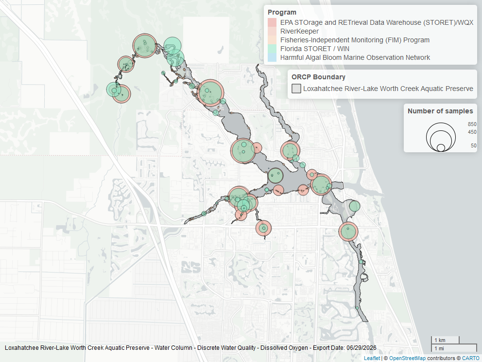

Map showing location of discrete water quality sampling locations within the boundaries of *Loxahatchee River-Lake Worth Creek Aquatic Preserve*. The bubble size on the maps above reflect the amount of data available at each sampling site.

### Dissolved Oxygen Saturation - Discrete

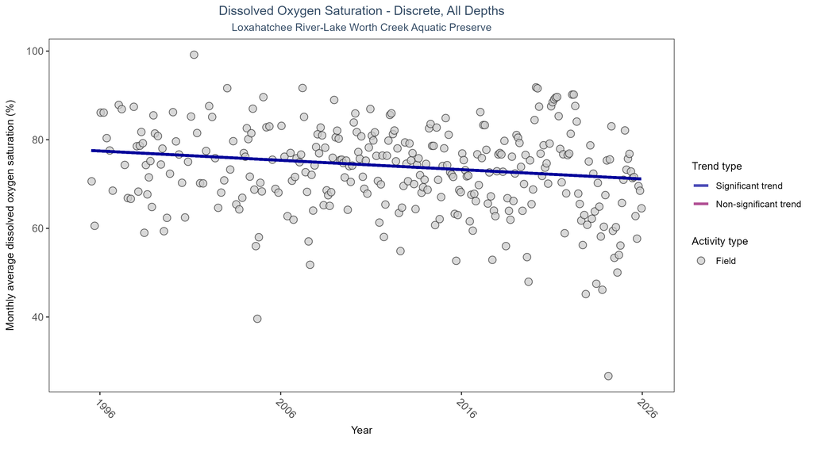

Scatter plot of monthly average dissolved oxygen saturation over time. If the time series included ten or more years of discrete observations, a significant (blue) or non-significant (magenta) trend line is also shown. Only dissolved oxygen saturation values measured in the field (circles) are included in the plot.

Table:

Monthly average dissolved oxygen saturation decreased by 0.21% per year.

| Activity Type | Statistical Trend | Sample Count | Years with Data | Period of Record | Median Result Value | Tau | Sen Intercept | Sen Slope | P |
| --- | --- | --- | --- | --- | --- | --- | --- | --- | --- |
| Field | Decreasing trend | 11226 | 31 | 1995 - 2025 | 76 | -0.15406 | 77.67006 | -0.2105 | 0.0001 |

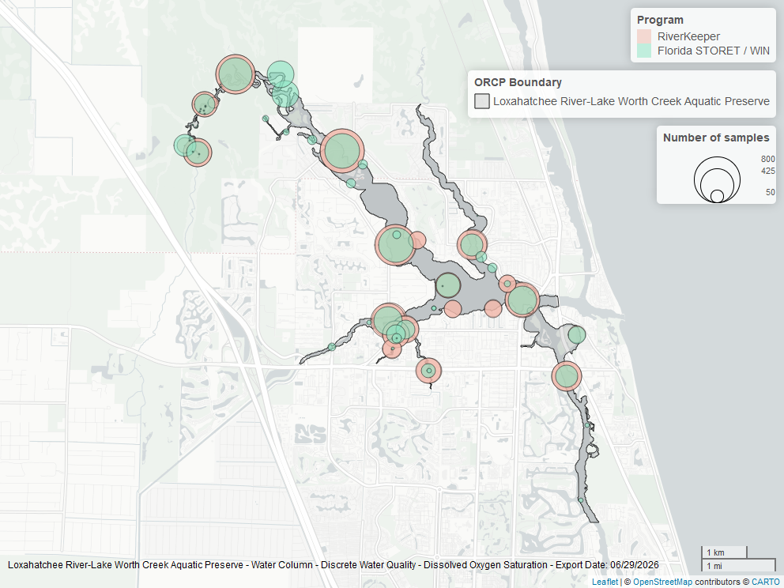

Map showing location of discrete water quality sampling locations within the boundaries of *Loxahatchee River-Lake Worth Creek Aquatic Preserve*. The bubble size on the maps above reflect the amount of data available at each sampling site.

### Salinity - Discrete

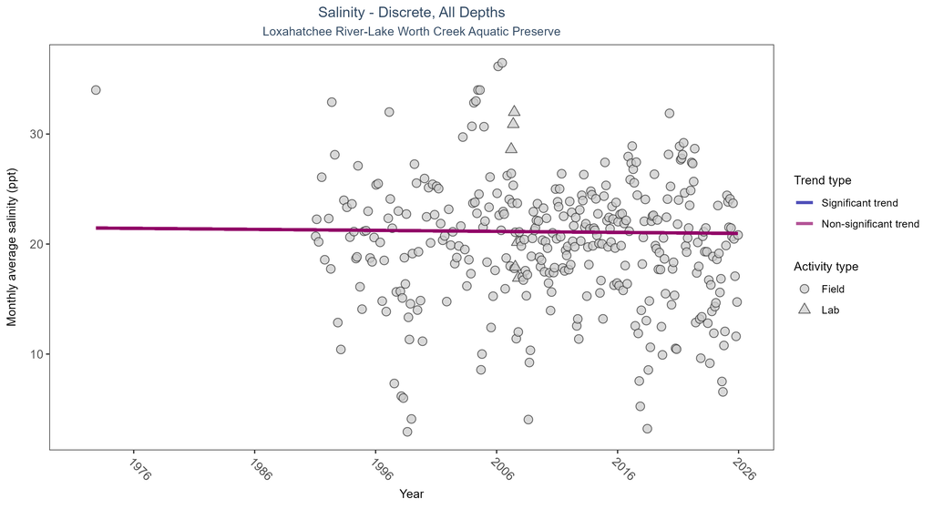

Scatter plot of monthly average salinity over time. If the time series included ten or more years of discrete observations, significant (blue) or non-significant (magenta) trend lines are also shown. Discrete salinity values derived from grab samples analyzed in the field (circles) or the laboratory (triangles) are both included in the plot.

Table:

Salinity showed no detectable trend between 1972 and 2025.

| Activity Type | Statistical Trend | Sample Count | Years with Data | Period of Record | Median Result Value | Tau | Sen Intercept | Sen Slope | P |
| --- | --- | --- | --- | --- | --- | --- | --- | --- | --- |
| All | No detectable trend | 12306 | 36 | 1972 - 2025 | 24.4 | -0.00982 | 21.46318 | -0.00921 | 0.7936 |

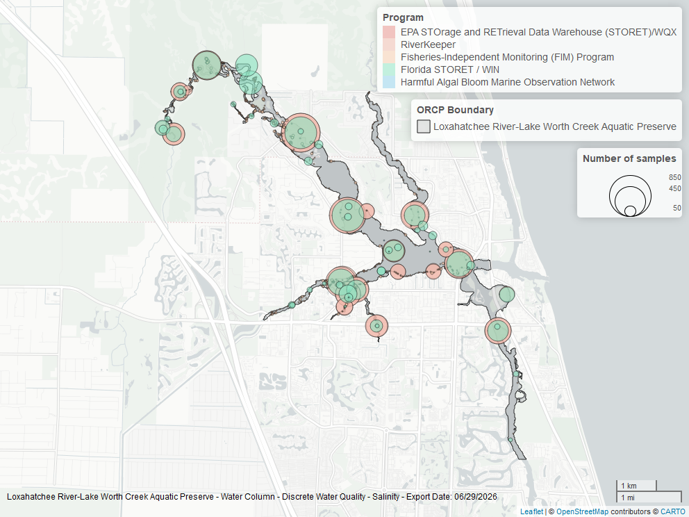

Map showing location of discrete water quality sampling locations within the boundaries of *Loxahatchee River-Lake Worth Creek Aquatic Preserve*. The bubble size on the maps above reflect the amount of data available at each sampling site.

### Salinity - Continuous

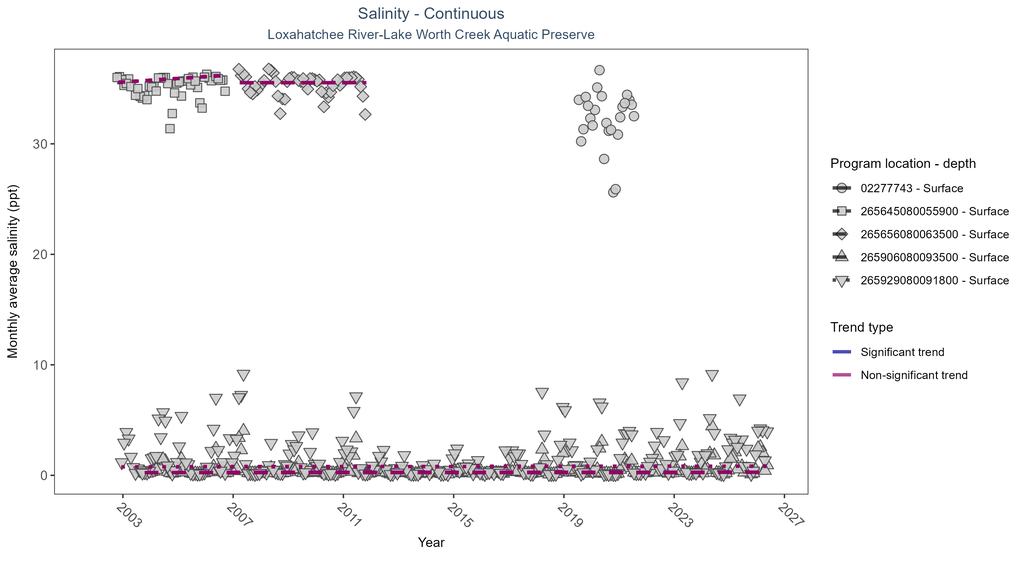

Scatter plot of monthly average salinity over time at continuously monitored program locations. Each location is analyzed separately, with significant (blue) or non-significant (magenta) trend lines shown for time series that included five or more years of observations.

Table:

No detectable change in monthly average salinity was observed at four locations. There was insufficient data to fit a model for one location.

| Program Location | Statistical Trend | Sample Count | Years with Data | Period of Record | Median Result Value | Tau | Sen Intercept | Sen Slope | P |
| --- | --- | --- | --- | --- | --- | --- | --- | --- | --- |
| 02277743 | Insufficient data | 1144 | 3 | 2019 - 2021 | 32.0 | - | - | - | - |
| 265645080055900 | No detectable trend | 1354 | 5 | 2002 - 2006 | 36.0 | 0.22 | 35.43 | 0.16 | 0.16 |
| 265656080063500 | No detectable trend | 2046 | 5 | 2007 - 2011 | 36.0 | 0.01 | 35.53 | 0 | 1 |
| 265906080093500 | No detectable trend | 9690 | 24 | 2003 - 2026 | 0.3 | 0.05 | 0.25 | 0 | 0.23 |
| 265929080091800 | No detectable trend | 8362 | 25 | 2002 - 2026 | 0.4 | 0.04 | 0.76 | 0 | 0.33 |

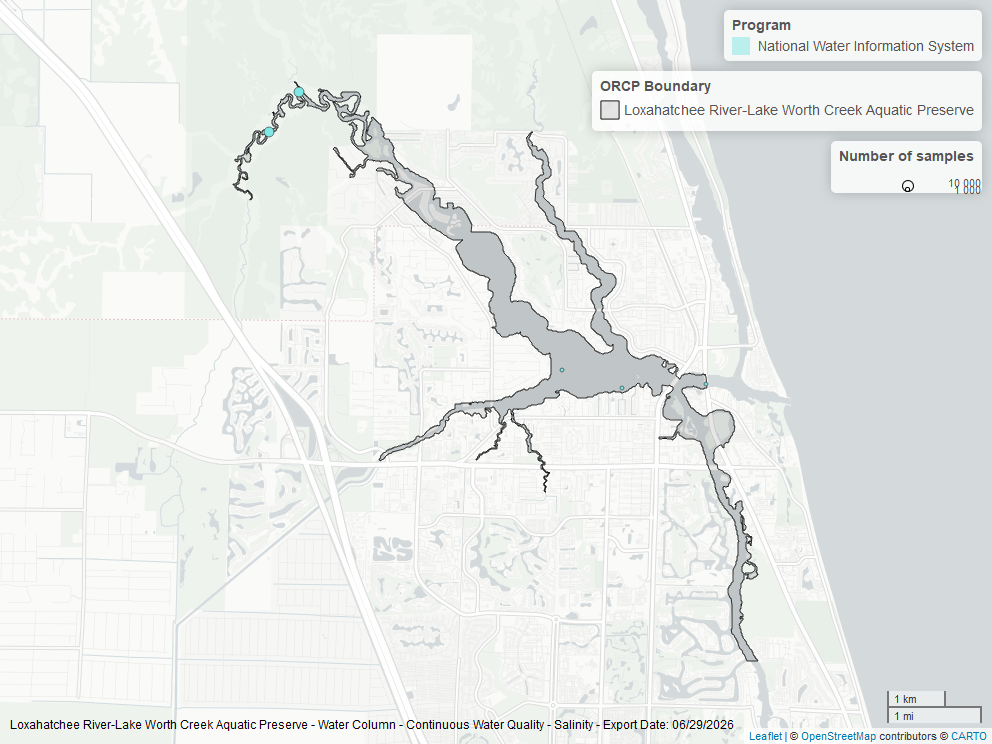

Map showing location of salinity continuous water quality sampling locations within the boundaries of *Loxahatchee River-Lake Worth Creek Aquatic Preserve*. The bubble size on the maps above reflect the amount of data available at each sampling site.

### Water Temperature - Continuous

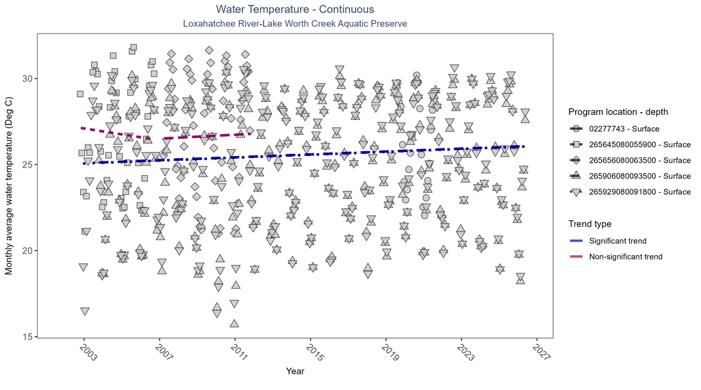

Scatter plot of monthly average water temperature over time at continuously monitored program locations. Each location is analyzed separately, with significant (blue) or non-significant (magenta) trend lines shown for time series that included five or more years of observations.

Table:

At two program locations, monthly average water temperature increased by 0.04°C per year. No detectable change in monthly average water temperature was observed at two locations. There was insufficient data to fit a model for one location.

| Program Location | Statistical Trend | Sample Count | Years with Data | Period of Record | Median Result Value | Tau | Sen Intercept | Sen Slope | P |
| --- | --- | --- | --- | --- | --- | --- | --- | --- | --- |
| 02277743 | Insufficient data | 1122 | 3 | 2019 - 2021 | 26.3 | - | - | - | - |
| 265645080055900 | No detectable trend | 1354 | 5 | 2002 - 2006 | 26.6 | -0.29 | 27.27 | -0.17 | 0.07 |
| 265656080063500 | No detectable trend | 2664 | 5 | 2007 - 2011 | 27.6 | 0.08 | 26.5 | 0.06 | 0.45 |
| 265906080093500 | Increasing trend | 12760 | 24 | 2003 - 2026 | 25.6 | 0.26 | 25.08 | 0.04 | 0 |
| 265929080091800 | Increasing trend | 8383 | 25 | 2002 - 2026 | 25.7 | 0.23 | 25.02 | 0.04 | 0 |

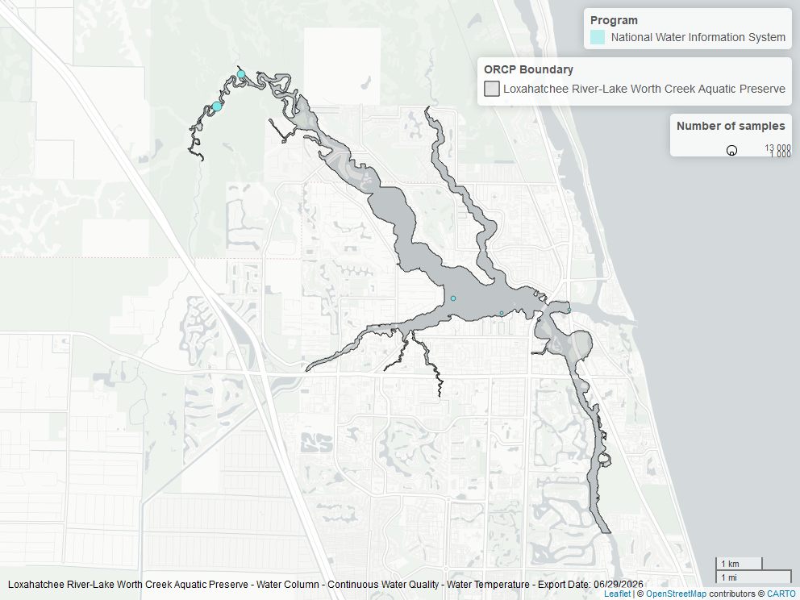

Map showing location of water temperature continuous water quality sampling locations within the boundaries of *Loxahatchee River-Lake Worth Creek Aquatic Preserve*. The bubble size on the maps above reflect the amount of data available at each sampling site.

### Water Temperature - Discrete

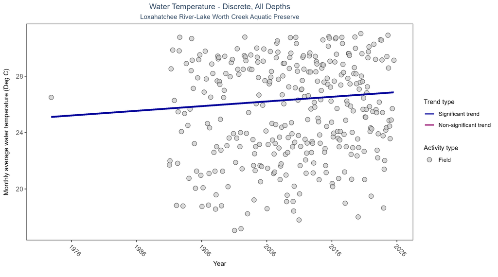

Scatter plot of monthly average water temperature over time. If the time series included ten or more years of discrete observations, a significant (blue) or non-significant (magenta) trend line is also shown. Only water temperature measurements taken in the field (circles) are included in the plot.

Table:

Monthly average water temperature increased by 0.03°C per year.

| Activity Type | Statistical Trend | Sample Count | Years with Data | Period of Record | Median Result Value | Tau | Sen Intercept | Sen Slope | P |
| --- | --- | --- | --- | --- | --- | --- | --- | --- | --- |
| Field | Increasing trend | 10905 | 36 | 1972 - 2025 | 25.6 | 0.15429 | 25.08312 | 0.03314 | 0.0001 |

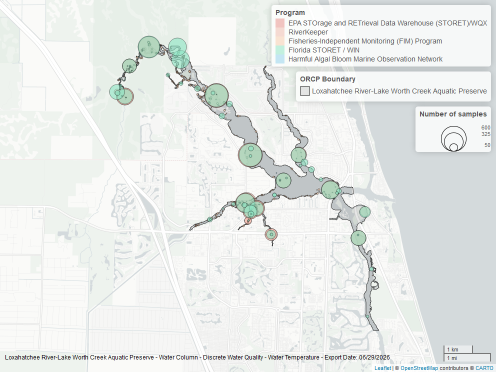

Map showing location of discrete water quality sampling locations within the boundaries of *Loxahatchee River-Lake Worth Creek Aquatic Preserve*. The bubble size on the maps above reflect the amount of data available at each sampling site.

### pH - Discrete

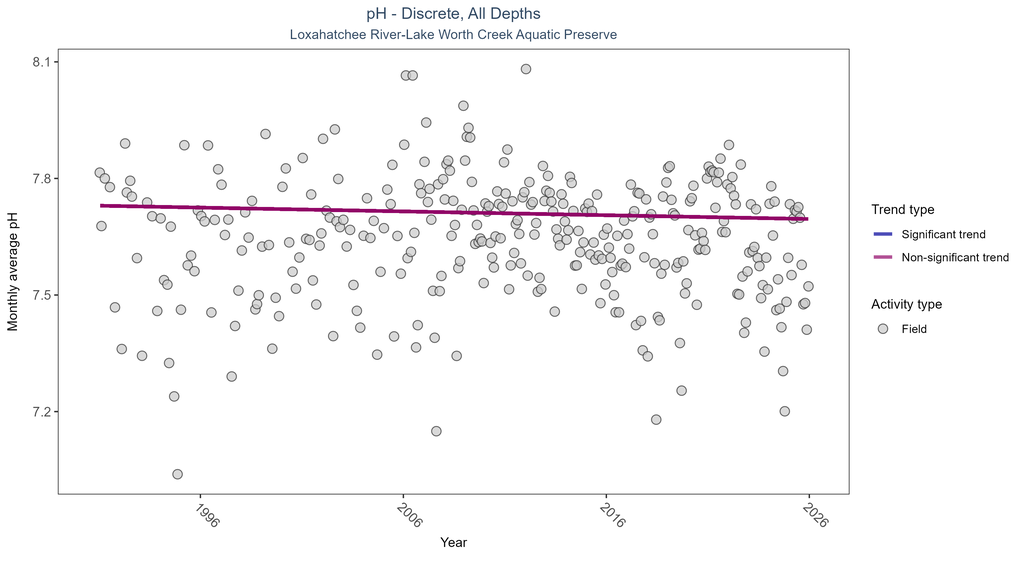

Scatter plot of monthly average pH over time. If the time series included ten or more years of discrete observations, a significant (blue) or non-significant (magenta) trend line is also shown. Only pH values measured in the field (circles) are included in the plot.

Table:

pH showed no detectable trend between 1991 and 2025.

| Activity Type | Statistical Trend | Sample Count | Years with Data | Period of Record | Median Result Value | Tau | Sen Intercept | Sen Slope | P |
| --- | --- | --- | --- | --- | --- | --- | --- | --- | --- |
| Field | No detectable trend | 12916 | 35 | 1991 - 2025 | 7.7 | -0.06325 | 7.72989 | -0.00098 | 0.2676 |

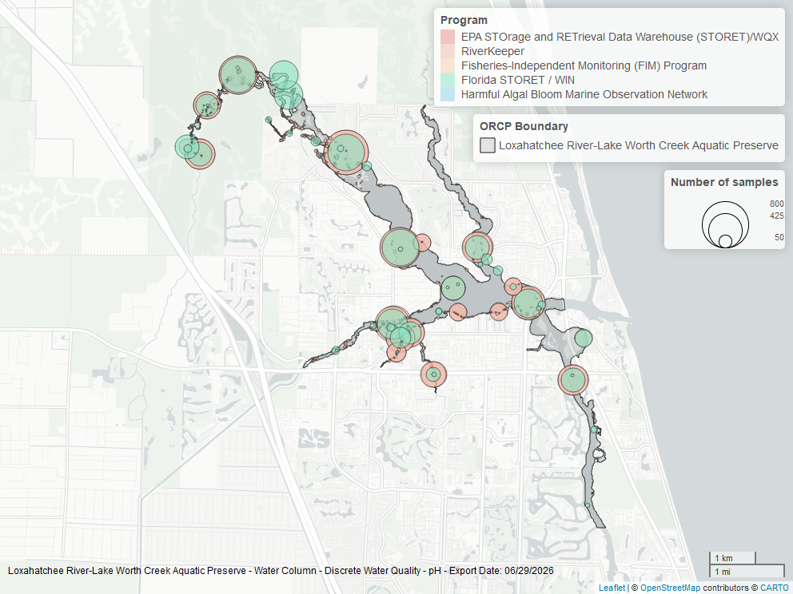

Map showing location of discrete water quality sampling locations within the boundaries of *Loxahatchee River-Lake Worth Creek Aquatic Preserve*. The bubble size on the maps above reflect the amount of data available at each sampling site.

### Specific Conductivity - Continuous

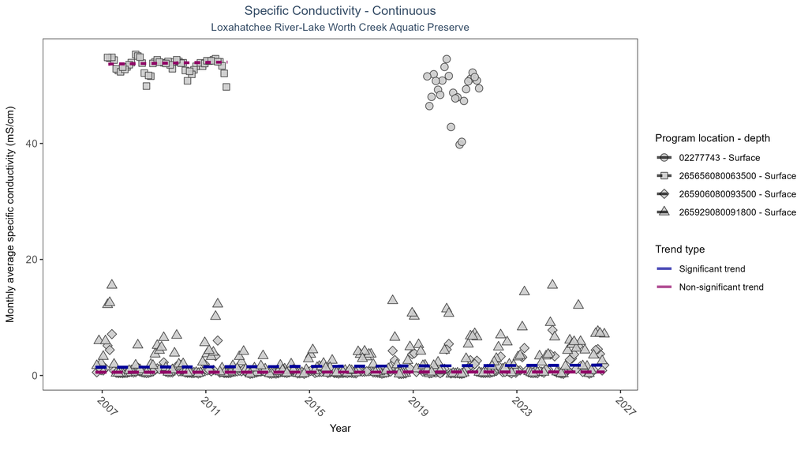

Scatter plot of monthly average specific conductivity over time at continuously monitored program locations. Each location is analyzed separately, with significant (blue) or non-significant (magenta) trend lines shown for time series that included five or more years of observations.

Table:

At one program location, monthly average specific conductivity increased by 0.02 mS/cm per year. No detectable change in monthly average specific conductivity was observed at two locations. There was insufficient data to fit a model for one location.

| Program Location | Statistical Trend | Sample Count | Years with Data | Period of Record | Median Result Value | Tau | Sen Intercept | Sen Slope | P |
| --- | --- | --- | --- | --- | --- | --- | --- | --- | --- |
| 02277743 | Insufficient data | 1425 | 3 | 2019 - 2021 | 50.10 | - | - | - | - |
| 265656080063500 | No detectable trend | 2550 | 5 | 2007 - 2011 | 53.90 | 0.04 | 53.66 | 0.08 | 0.93 |
| 265906080093500 | No detectable trend | 13751 | 21 | 2006 - 2026 | 0.56 | 0.07 | 0.55 | 0 | 0.14 |
| 265929080091800 | Increasing trend | 6917 | 21 | 2006 - 2026 | 0.85 | 0.11 | 1.41 | 0.02 | 0.02 |

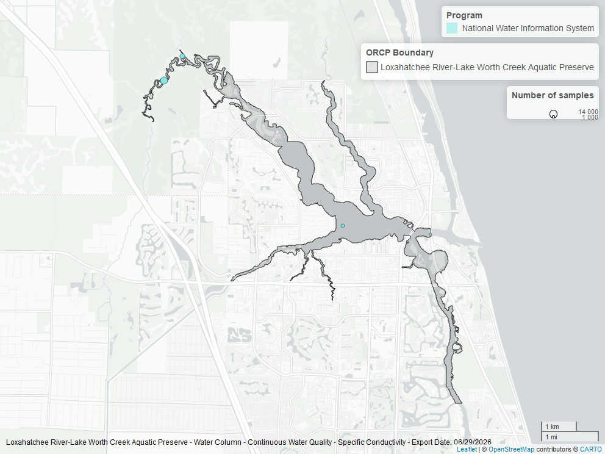

Map showing location of specific conductivity continuous water quality sampling locations within the boundaries of *Loxahatchee River-Lake Worth Creek Aquatic Preserve*. The bubble size on the maps above reflect the amount of data available at each sampling site.

## Water Clarity

### Turbidity - Discrete

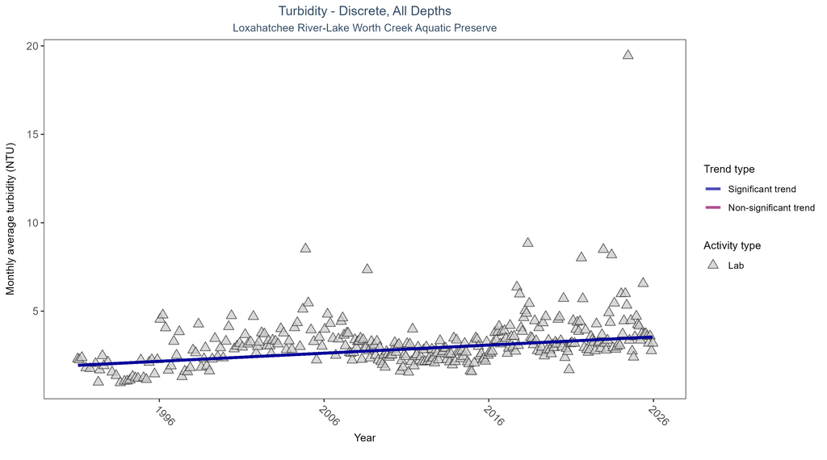

Scatter plot of monthly average turbidity over time. If the time series included ten or more years of discrete observations, a significant (blue) or non-significant (magenta) trend line is also shown. Only turbidity values measured in the laboratory (triangles) are included in the plot.

Table:

Monthly average turbidity increased by 0.05 NTU per year, indicating a decrease in water clarity.

| Activity Type | Statistical Trend | Sample Count | Years with Data | Period of Record | Median Result Value | Tau | Sen Intercept | Sen Slope | P |
| --- | --- | --- | --- | --- | --- | --- | --- | --- | --- |
| Lab | Increasing trend | 6632 | 35 | 1991 - 2025 | 2.7 | 0.3358 | 1.93661 | 0.04586 | 0 |

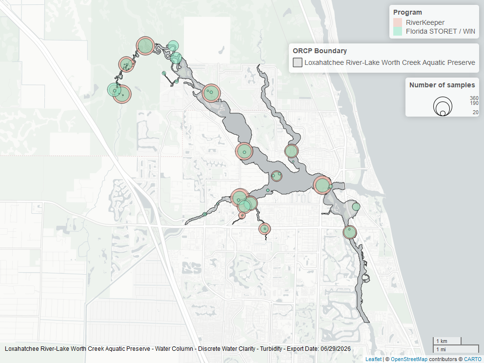

Map showing location of discrete water quality sampling locations within the boundaries of *Loxahatchee River-Lake Worth Creek Aquatic Preserve*. The bubble size on the maps above reflect the amount of data available at each sampling site.

### Total Suspended Solids - Discrete

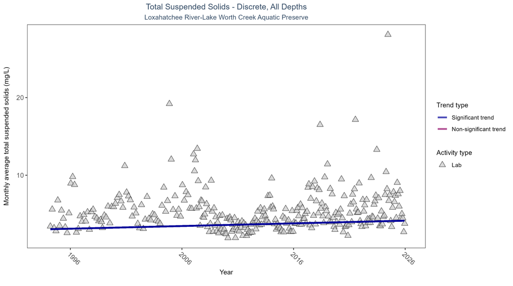

Scatter plot of monthly average total suspended solids (TSS) over time. If the time series included ten or more years of discrete observations, a significant (blue) or non-significant (magenta) trend line is also shown. Only TSS values obtained from laboratory analyses (triangles) are included in the plot.

Table:

Monthly average total suspended solids increased by 0.03 mg/L per year, indicating a decrease in water clarity.

| Activity Type | Statistical Trend | Sample Count | Years with Data | Period of Record | Median Result Value | Tau | Sen Intercept | Sen Slope | P |
| --- | --- | --- | --- | --- | --- | --- | --- | --- | --- |
| Lab | Increasing trend | 6264 | 32 | 1994 - 2025 | 4 | 0.14544 | 3.0446 | 0.03434 | 0.0056 |

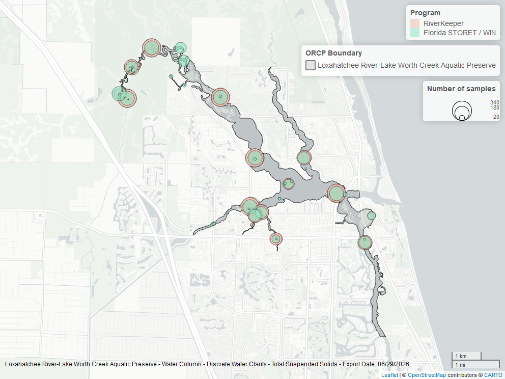

Map showing location of discrete water quality sampling locations within the boundaries of *Loxahatchee River-Lake Worth Creek Aquatic Preserve*. The bubble size on the maps above reflect the amount of data available at each sampling site.

### Chlorophyll a, Uncorrected for Pheophytin - Discrete

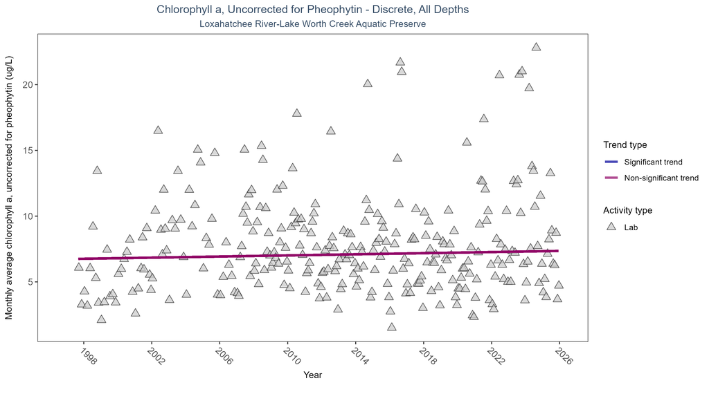

Scatter plot of monthly average levels of chlorophyll a, uncorrected for pheophytin, over time. If the time series included ten or more years of discrete observations, a significant (blue) or non-significant (magenta) trend line is also shown. Only laboratory-analyzed chlorophyll a (triangles) is included in the plot.

Table:

Chlorophyll a, uncorrected for pheophytin, showed no detectable trend between 1997 and 2025.

| Activity Type | Statistical Trend | Sample Count | Years with Data | Period of Record | Median Result Value | Tau | Sen Intercept | Sen Slope | P |
| --- | --- | --- | --- | --- | --- | --- | --- | --- | --- |
| Lab | No detectable trend | 6007 | 29 | 1997 - 2025 | 5.6 | 0.03611 | 6.73567 | 0.02125 | 0.3828 |

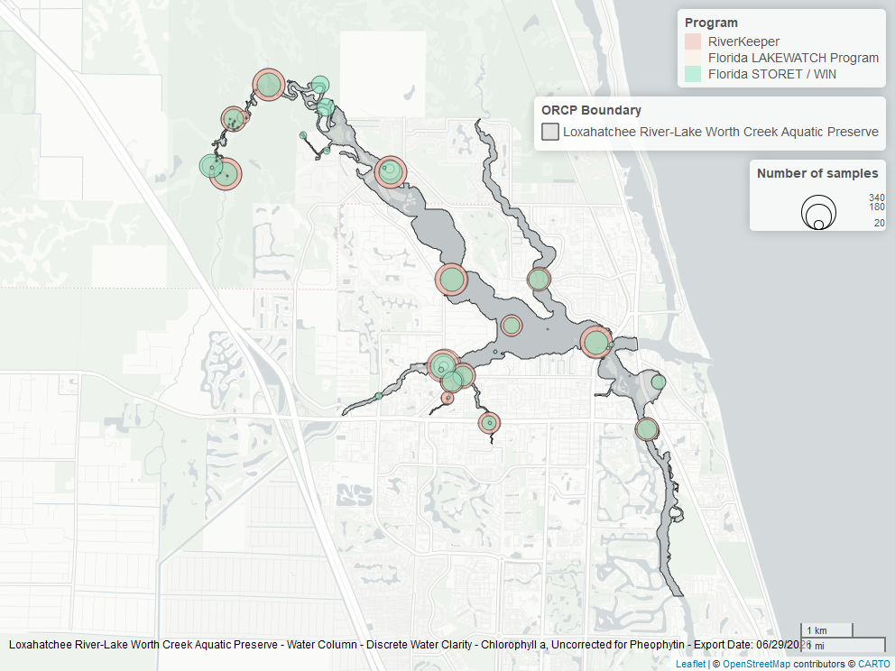

Map showing location of discrete water quality sampling locations within the boundaries of *Loxahatchee River-Lake Worth Creek Aquatic Preserve*. The bubble size on the maps above reflect the amount of data available at each sampling site.

### Chlorophyll a, Corrected for Pheophytin - Discrete

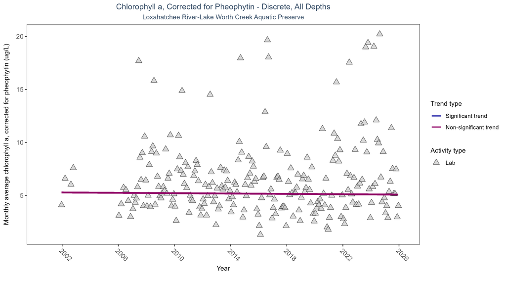

Scatter plot of monthly average levels of chlorophyll a, corrected for pheophytin, over time. If the time series included ten or more years of discrete observations, a significant (blue) or non-significant (magenta) trend line is also shown. Only laboratory-analyzed chlorophyll a (triangles) is included in the plot.

Table:

Chlorophyll a, corrected for pheophytin, showed no detectable trend between 2001 and 2025.

| Activity Type | Statistical Trend | Sample Count | Years with Data | Period of Record | Median Result Value | Tau | Sen Intercept | Sen Slope | P |
| --- | --- | --- | --- | --- | --- | --- | --- | --- | --- |
| Lab | No detectable trend | 4638 | 22 | 2001 - 2025 | 4.5 | -0.01408 | 5.28487 | -0.00825 | 0.7474 |

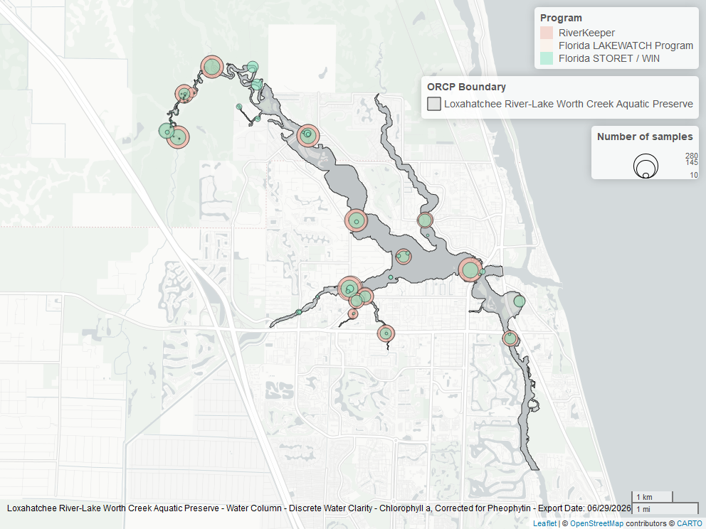

Map showing location of discrete water quality sampling locations within the boundaries of *Loxahatchee River-Lake Worth Creek Aquatic Preserve*. The bubble size on the maps above reflect the amount of data available at each sampling site.

### Secchi Depth - Discrete

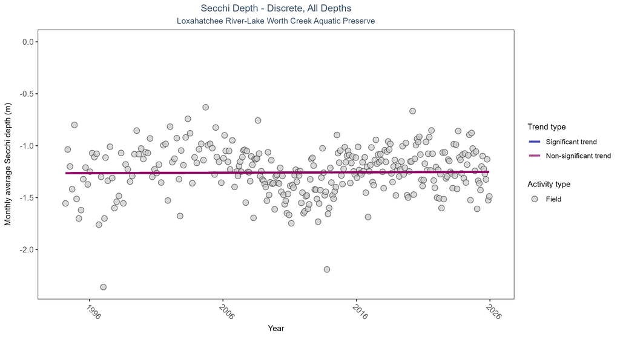

Scatter plot of monthly average Secchi depth over time. If the time series included ten or more years of discrete observations, a significant (blue) or non-significant (magenta) trend line is also shown. Secchi depth is only measured in the field (circles).

Table:

Secchi depth showed no detectable trend between 1994 and 2025.

| Activity Type | Statistical Trend | Sample Count | Years with Data | Period of Record | Median Result Value | Tau | Sen Intercept | Sen Slope | P |
| --- | --- | --- | --- | --- | --- | --- | --- | --- | --- |
| Field | No detectable trend | 5062 | 32 | 1994 - 2025 | -1.2 | 0.04058 | -1.26426 | 0.00036 | 0.8485 |

[figure not shown]

Map showing location of discrete water quality sampling locations within the boundaries of *Loxahatchee River-Lake Worth Creek Aquatic Preserve*. The bubble size on the maps above reflect the amount of data available at each sampling site.

### Colored Dissolved Organic Matter - Discrete

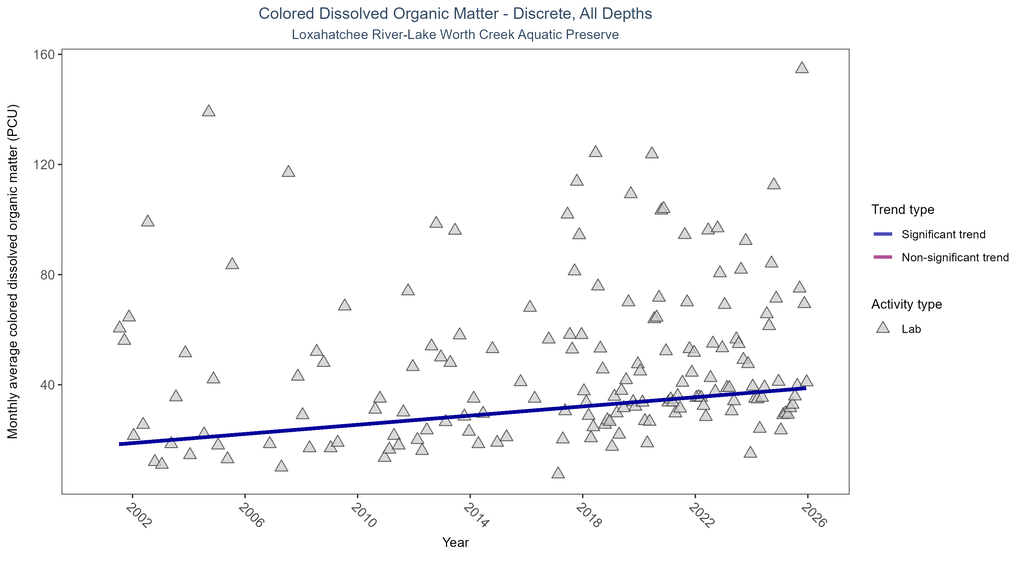

Scatter plot of monthly average colored dissolved organic matter (CDOM) over time. If the time series included ten or more years of discrete observations, a significant (blue) or non-significant (magenta) trend line is also shown. Only laboratory-analyzed CDOM (triangles) is included in the plot.

Table:

Monthly average colored dissolved organic matter increased by 0.83 PCU per year, indicating a decrease in water clarity.

| Activity Type | Statistical Trend | Sample Count | Years with Data | Period of Record | Median Result Value | Tau | Sen Intercept | Sen Slope | P |
| --- | --- | --- | --- | --- | --- | --- | --- | --- | --- |
| Lab | Increasing trend | 1291 | 25 | 2001 - 2025 | 45 | 0.25694 | 17.96211 | 0.83333 | 0 |

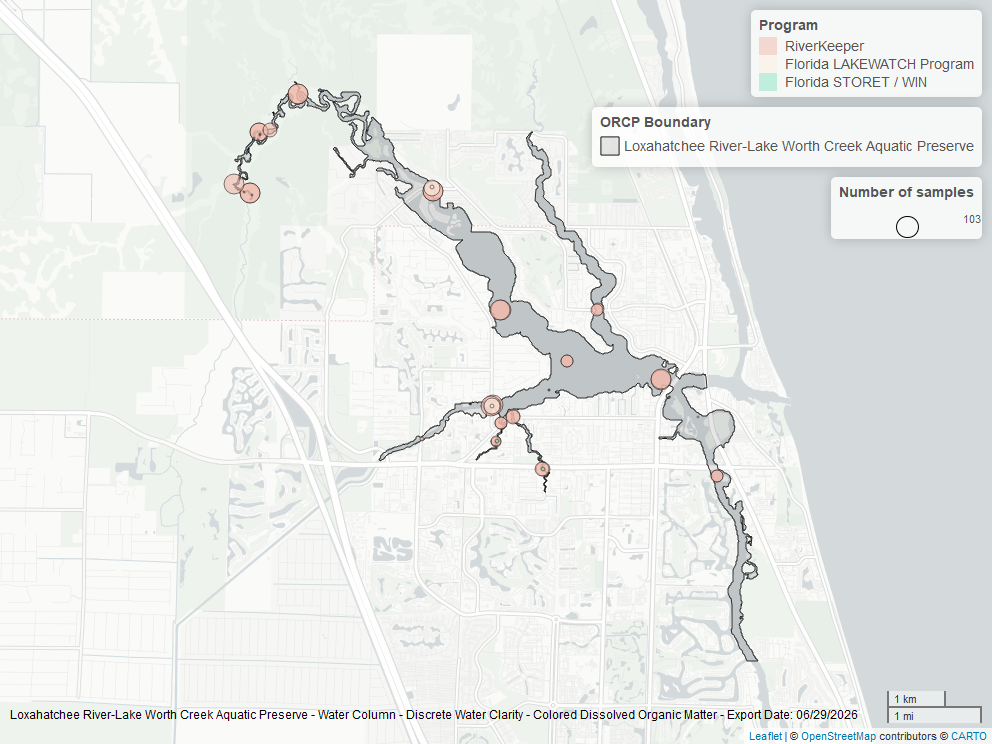

Map showing location of discrete water quality sampling locations within the boundaries of *Loxahatchee River-Lake Worth Creek Aquatic Preserve*. The bubble size on the maps above reflect the amount of data available at each sampling site.